# Past Pandemics City Zuerich

# Methods

- Estimation of excess mortality using a Bayesian approach (INLA)
- Expected values estimated including 5 prior years
- Poisson regression
- Random effects: Time, Year, Temperatur (for weekly data)

Orange areas are periods of heat waves, blue areas cold waves, gray areas are periods of more sever pandemics/epidemics/influenza waves.

# Weekly data

- To estimate the weekly population data, linear interpolation between the yearly population was performed.
- Weekly death data only available until 1960

```r
hyper.iid <- list(theta = list(prior="pc.prec", param=c(1, 0.01)))

 formula <- death ~ 1 + offset(log(pop.weekly))  +
    f(WeekID, model='iid',hyper=hyper.iid) +
    f(timeID, model='rw1',scale.model = T,cyclic = TRUE, hyper=hyper.iid) +
    f(TempID, model='rw2',hyper=hyper.iid)

inla.mod <- inla(formula,
                     data=reg_data,
                     family="Poisson",
                     control.family = control.family,
                     control.compute = list(config = TRUE),
                     control.mode = list(restart = TRUE),
                     control.predictor = list(compute = TRUE, link = 1))
```

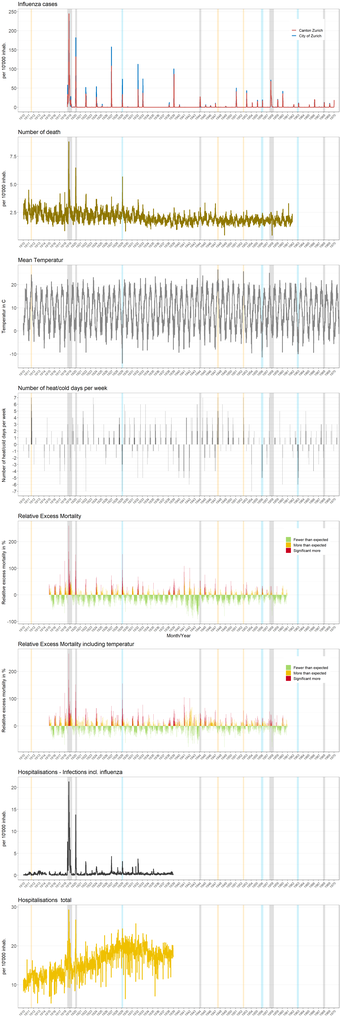

# Monthly Data

- To estimate the monthly population data, linear interpolation between the yearly population was performed.
- Transformation from weekly to monthly death and influenza data using the package wktmo and weekToMonth() function
- December 1961 is not complete and missing from the analysis (also excluded by estimation of expected value)

```r
hyper.iid <- list(theta = list(prior="pc.prec", param=c(1, 0.01)))


 formula <- death ~ 1 + offset(log(pop.monthly))  +
    f(MonthID, model='iid',hyper=hyper.iid) +
    f(timeID, model='seasonal', season.length = 12)

inla.mod <- inla(formula,
                     data=reg_data,
                     family="Poisson",
                     control.family = control.family,
                     control.compute = list(config = TRUE),
                     control.mode = list(restart = TRUE),
                     control.predictor = list(compute = TRUE, link = 1))
```

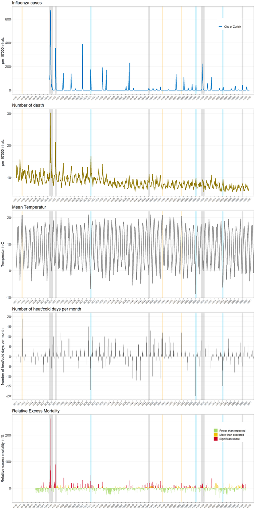

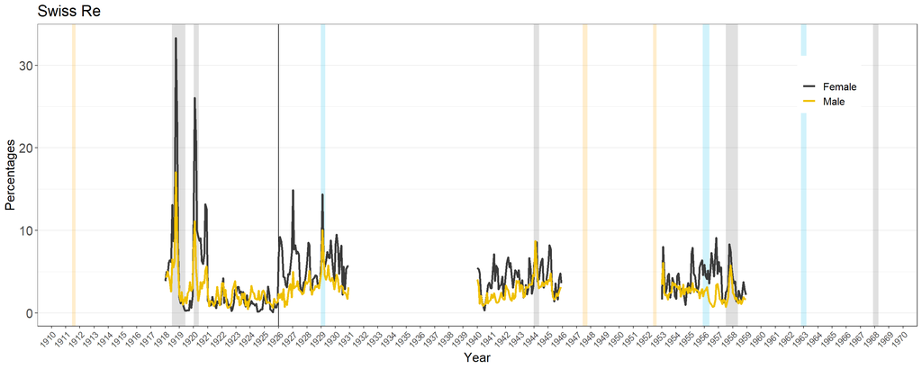

# Yearly Data

- To estimate the monthly population data, linear interpolation between the yearly population was performed.
- Transformation from weekly to monthly death and influenza data using the package wktmo and weekToMonth() function
- December 1961 is not complete and missing from the analysis (also excluded by estimation of expected value)

```r
hyper.iid <- list(theta = list(prior="pc.prec", param=c(1, 0.01)))

  formula <- death ~ 1 + offset(log(pop.monthly)) +
    f(YearID,model='iid',hyper=hyper.iid) +
    f(timeID, model='seasonal', season.length = 12)

inla.mod <- inla(formula,
                     data=reg_data,
                     family="Poisson",
                     control.family = control.family,
                     control.compute = list(config = TRUE),
                     control.mode = list(restart = TRUE),
                     control.predictor = list(compute = TRUE, link = 1))
```

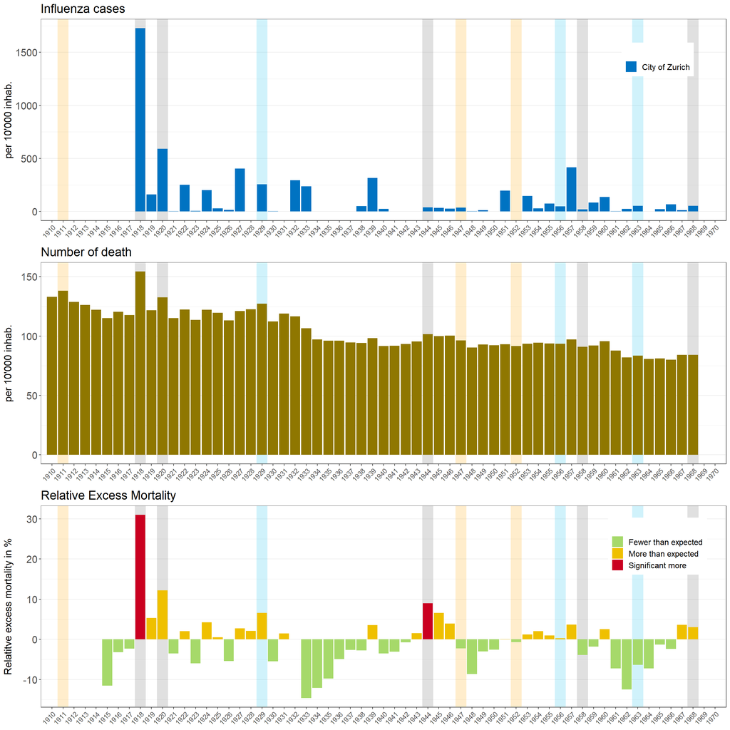

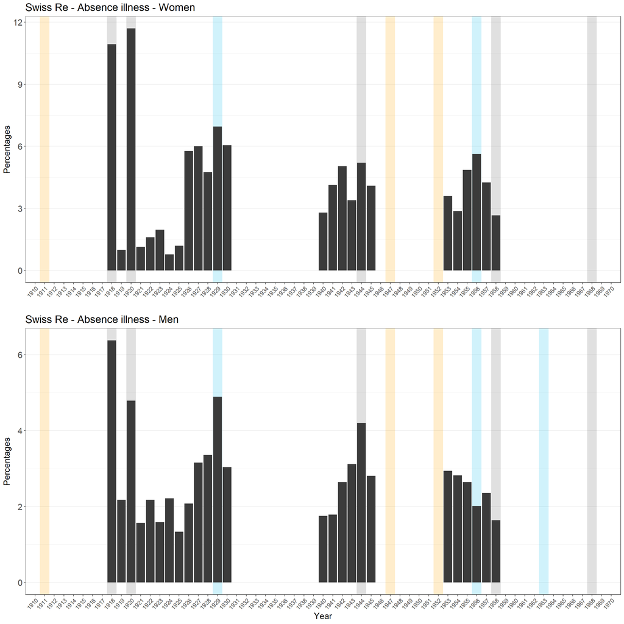

# Reporting weeks

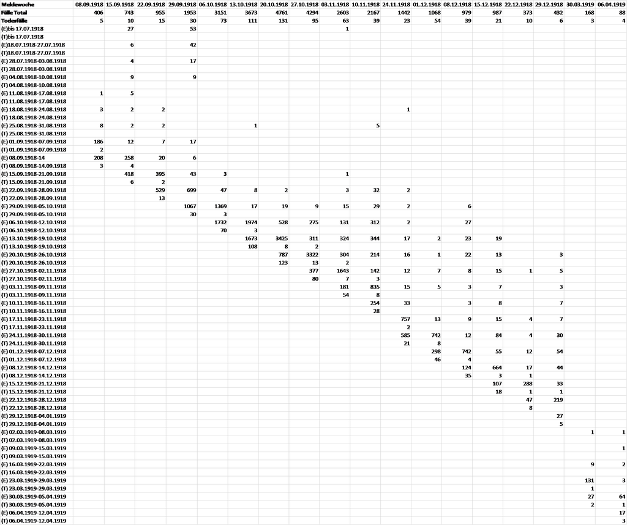